# BVP layer -- Solve a singular perturbation problem

[AMath 585, Winter Quarter 2020](http://staff.washington.edu/rjl/classes/am585w2020/) at the University of Washington. Developed by R.J. LeVeque and distributed under the [BSD license](https://github.com/rjleveque/amath585w2020/blob/master/LICENSE). You are free to modify and use as you please, with attribution.

These notebooks are all [available on Github](https://github.com/rjleveque/amath585w2020/).

Solve the nonlinear BVP $$ \epsilon u''(x) + u(x)(u'(x) - 1) = f(x) $$ with Dirichlet boundary conditions.

In this notebook we consider the case where $\epsilon > 0$ is very small, the singular perturbation problem discussed in Section 2.17 of the textbook.

*Continuation* in both $\epsilon$ and the size of the system are illustrated as well.

```python
%matplotlib inline
```

```python
from pylab import *
```

```python
from scipy.interpolate import interp1d  # used for continuation
```

The `BVP_nonlinear.py` module contains the function `solve_bvp_nonlinear` that is illustrated in the notebook BVP_nonlinear.html.

```python
from BVP_nonlinear import solve_bvp_nonlinear
```

```python
ax = 0.; alpha = -1.; ainfo = (ax, alpha)
bx = 1.; beta = 1.5;   binfo = (bx, beta)
f = lambda x: zeros(x.shape) # the zero function

xbar = 0.5*(ax+bx-beta-alpha)
print('For small epsilon we expect a layer near xbar = %.2f' % xbar)
```

```
For small epsilon we expect a layer near xbar = 0.25
```

```
Iteration k = 0: norm(Gk) = 2.17e+00, norm(delta) = 6.80e-01
Iteration k = 1: norm(Gk) = 1.12e+00, norm(delta) = 1.37e-01
Iteration k = 2: norm(Gk) = 9.45e-02, norm(delta) = 4.62e-03
Iteration k = 3: norm(Gk) = 1.46e-04, norm(delta) = 5.23e-06
Iteration k = 4: norm(Gk) = 1.58e-10, norm(delta) = 5.71e-12
Iteration k = 5: norm(Gk) = 9.46e-14, norm(delta) = 2.11e-15
Declared convergence after 5 iterations
```

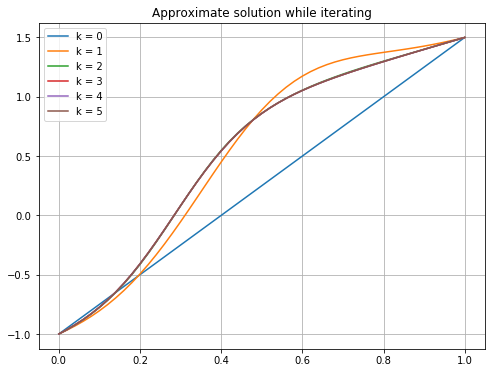

```python
epsilon = 0.1
m = 49
u0_func = lambda x: alpha + x * (beta-alpha) / (bx-ax)
x,u = solve_bvp_nonlinear(epsilon, f, ainfo, binfo, m, u0_func)
```

For smaller epsilon we see slower convergence and some wonky looking iterates, but the final solution looks smooth with a layer where we expect it:

```
Iteration k = 0: norm(Gk) = 2.23e+00, norm(delta) = 1.84e+00
Iteration k = 1: norm(Gk) = 2.43e+01, norm(delta) = 2.40e+00
Iteration k = 2: norm(Gk) = 1.23e+02, norm(delta) = 2.02e+00
Iteration k = 3: norm(Gk) = 1.58e+02, norm(delta) = 1.18e+00
Iteration k = 4: norm(Gk) = 6.27e+01, norm(delta) = 5.40e-01
Iteration k = 5: norm(Gk) = 1.39e+01, norm(delta) = 1.34e-01
Iteration k = 6: norm(Gk) = 8.30e-01, norm(delta) = 7.77e-03
Iteration k = 7: norm(Gk) = 3.16e-03, norm(delta) = 2.53e-05
Iteration k = 8: norm(Gk) = 3.15e-08, norm(delta) = 2.55e-10
Iteration k = 9: norm(Gk) = 1.06e-13, norm(delta) = 3.07e-15
Declared convergence after 9 iterations
```

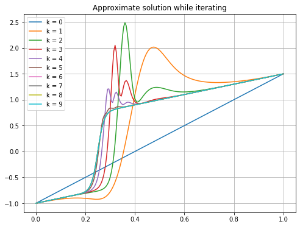

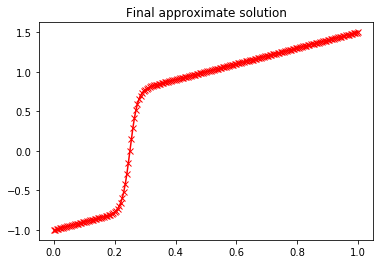

```python
epsilon = 0.01
m = 199
u0_func = lambda x: alpha + x * (beta-alpha) / (bx-ax)
x,u = solve_bvp_nonlinear(epsilon, f, ainfo, binfo, m, u0_func)

figure()
plot(x,u,'rx-')
title('Final approximate solution')
```

Note that we have many grid points in the layer. If we tried this value of epsilon with fewer grid points the final solution won't look so nice, and/or Newton's method might not converge.

Here we see that it doesn't converge when the starting guess is the linear function:

```
Iteration k = 0: norm(Gk) = 2.17e+00, norm(delta) = 1.85e+00
Iteration k = 1: norm(Gk) = 2.38e+01, norm(delta) = 2.82e+00
Iteration k = 2: norm(Gk) = 1.12e+02, norm(delta) = 3.63e+00
Iteration k = 3: norm(Gk) = 4.56e+02, norm(delta) = 5.73e+00
Iteration k = 4: norm(Gk) = 4.73e+02, norm(delta) = 9.50e+00
Iteration k = 5: norm(Gk) = 1.46e+03, norm(delta) = 1.34e+01
Iteration k = 6: norm(Gk) = 9.02e+02, norm(delta) = 1.25e+01
Iteration k = 7: norm(Gk) = 2.50e+03, norm(delta) = 2.29e+01
Iteration k = 8: norm(Gk) = 8.03e+03, norm(delta) = 2.47e+01
Iteration k = 9: norm(Gk) = 1.78e+03, norm(delta) = 5.10e+01
Iteration k = 10: norm(Gk) = 2.26e+04, norm(delta) = 3.48e+01
Iteration k = 11: norm(Gk) = 4.97e+03, norm(delta) = 2.17e+01
Iteration k = 12: norm(Gk) = 1.90e+03, norm(delta) = 5.02e+01
Iteration k = 13: norm(Gk) = 6.20e+04, norm(delta) = 2.40e+01
Iteration k = 14: norm(Gk) = 1.48e+04, norm(delta) = 1.10e+01
Reached max_iter, possible nonconvergence
```

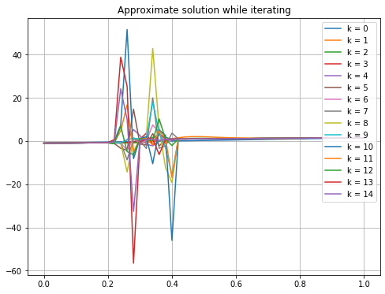

```python
epsilon = 0.01
m = 49
u0_func = lambda x: alpha + x * (beta-alpha) / (bx-ax)
x,u = solve_bvp_nonlinear(epsilon, f, ainfo, binfo, m,
                          u0_func, max_iter=15)
```

## Continuation

### Continuation in epsilon

To begin, let's keep `m = 49` fixed and try to get a better initial guess by first solving the problem with a larger `epsilon = 0.05` and save that solution so we can use it as an initial guess for the smaller value of `epsilon`.

```
Iteration k = 0: norm(Gk) = 2.17e+00, norm(delta) = 1.02e+00
Iteration k = 1: norm(Gk) = 3.36e+00, norm(delta) = 4.30e-01
Iteration k = 2: norm(Gk) = 1.28e+00, norm(delta) = 7.34e-02
Iteration k = 3: norm(Gk) = 5.34e-02, norm(delta) = 1.64e-03
Iteration k = 4: norm(Gk) = 3.37e-05, norm(delta) = 8.94e-07
Iteration k = 5: norm(Gk) = 7.36e-12, norm(delta) = 3.14e-13
Declared convergence after 5 iterations
```

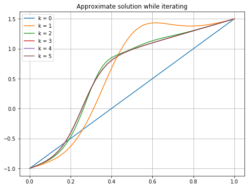

```python
epsilon = 0.05
m = 49
u0_func = lambda x: alpha + x * (beta-alpha) / (bx-ax)
x,u = solve_bvp_nonlinear(epsilon, f, ainfo, binfo, m,  u0_func)
u_05 = u
```

Now we can reduce `epsilon` and use the result just computed as the initial guess instead of a linear function.

Note that `u0_func` is a function that just returns this vector regardless of what `x` is passed in, so this wouldn't work if we wanted to increase `m` (which we will do later).

```
Iteration k = 0: norm(Gk) = 1.91e+00, norm(delta) = 6.59e-01
Iteration k = 1: norm(Gk) = 6.50e+00, norm(delta) = 2.00e-01
Iteration k = 2: norm(Gk) = 6.06e-01, norm(delta) = 1.86e-02
Iteration k = 3: norm(Gk) = 4.01e-03, norm(delta) = 1.08e-04
Iteration k = 4: norm(Gk) = 1.17e-07, norm(delta) = 2.08e-09
Iteration k = 5: norm(Gk) = 1.19e-14, norm(delta) = 3.80e-16
Declared convergence after 5 iterations
```

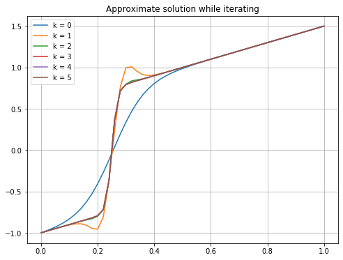

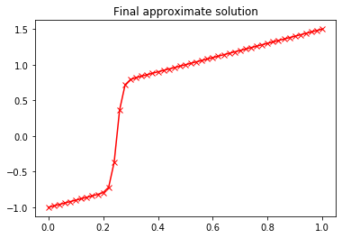

```python
epsilon = 0.01
m = 49
u0_func = lambda x: u_05
x,u = solve_bvp_nonlinear(epsilon, f, ainfo, binfo, m,  u0_func)
u_01 = u

figure()
plot(x,u,'rx-')
title('Final approximate solution')
```

Now Newton's method converges and we get something reasonable, even though there are only a few points in the interior layer.

We saved the solution above, which we can now use as initial guess for an even smaller `epsilon`:

```
Iteration k = 0: norm(Gk) = 2.89e+00, norm(delta) = 3.00e-01
Iteration k = 1: norm(Gk) = 2.89e+00, norm(delta) = 9.06e-01
Iteration k = 2: norm(Gk) = 1.86e+01, norm(delta) = 4.80e-01
Iteration k = 3: norm(Gk) = 5.31e+00, norm(delta) = 3.06e-01
Iteration k = 4: norm(Gk) = 2.19e+00, norm(delta) = 6.64e-01
Iteration k = 5: norm(Gk) = 1.04e+01, norm(delta) = 3.71e-01
Iteration k = 6: norm(Gk) = 3.26e+00, norm(delta) = 3.10e-01
Iteration k = 7: norm(Gk) = 2.27e+00, norm(delta) = 5.46e-01
Iteration k = 8: norm(Gk) = 7.05e+00, norm(delta) = 3.26e-01
Iteration k = 9: norm(Gk) = 2.51e+00, norm(delta) = 4.00e-01
Iteration k = 10: norm(Gk) = 3.79e+00, norm(delta) = 2.99e-01
Iteration k = 11: norm(Gk) = 2.11e+00, norm(delta) = 1.43e+00
Iteration k = 12: norm(Gk) = 4.80e+01, norm(delta) = 7.29e-01
Iteration k = 13: norm(Gk) = 1.26e+01, norm(delta) = 3.99e-01
Iteration k = 14: norm(Gk) = 3.77e+00, norm(delta) = 2.99e-01
Iteration k = 15: norm(Gk) = 2.12e+00, norm(delta) = 1.35e+00
Iteration k = 16: norm(Gk) = 4.34e+01, norm(delta) = 6.94e-01
Iteration k = 17: norm(Gk) = 1.14e+01, norm(delta) = 3.84e-01
Iteration k = 18: norm(Gk) = 3.49e+00, norm(delta) = 3.03e-01
Iteration k = 19: norm(Gk) = 2.18e+00, norm(delta) = 7.65e-01
Reached max_iter, possible nonconvergence
```

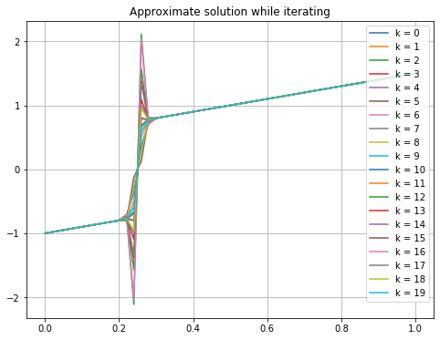

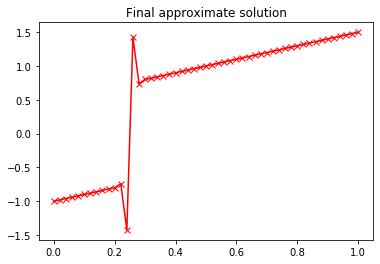

```python
epsilon = 0.007
m = 49
u0_func = lambda x: u_01
x,u = solve_bvp_nonlinear(epsilon, f, ainfo, binfo, m,  u0_func, max_iter=20)

figure()
plot(x,u,'rx-')
title('Final approximate solution')
```

### Continuation in m (refining the grid)

Newton's method wasn't converging in the test just done, and clearly we don't have enough grid points in the layer for this value of `epsilon`. So we might want to increase `m`. To do so we can define a function based on one of our previous converged solutions that we can then pass in as `u0_func` and that can be evaluated on a new finer grid.

To do so we use the [`scipy.interpolate.interp1d`](https://docs.scipy.org/doc/scipy/reference/generated/scipy.interpolate.interp1d.html) function that was imported at the top of this notebook, to define a piecewise linear function that interpolates the values `(x[i], u_01[i])`:

```python
u_01_func = interp1d(x,u_01,'linear')
```

```
Iteration k = 0: norm(Gk) = 8.99e+00, norm(delta) = 1.16e-01
Iteration k = 1: norm(Gk) = 3.23e-01, norm(delta) = 3.42e-03
Iteration k = 2: norm(Gk) = 4.81e-04, norm(delta) = 4.31e-06
Iteration k = 3: norm(Gk) = 6.38e-10, norm(delta) = 4.96e-12
Iteration k = 4: norm(Gk) = 2.95e-14, norm(delta) = 2.80e-15
Declared convergence after 4 iterations
```

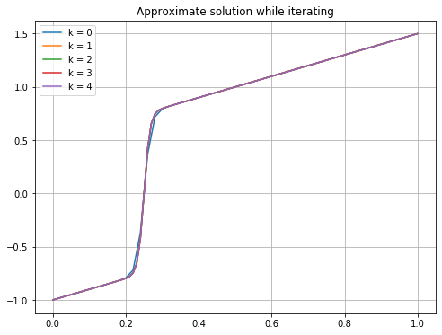

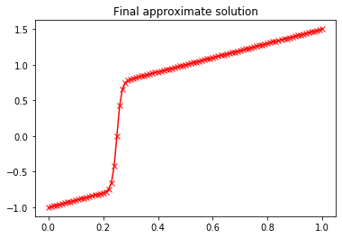

```python
epsilon = 0.007
m = 99
x,u = solve_bvp_nonlinear(epsilon, f, ainfo, binfo, m,  u0_func=u_01_func)

figure()
plot(x,u,'rx-')
title('Final approximate solution')
```

With this approach we can go to smaller `epsilon`, on a suitable fine grid:

```
Iteration k = 0: norm(Gk) = 1.13e+01, norm(delta) = 9.60e-01
Iteration k = 1: norm(Gk) = 1.00e+02, norm(delta) = 3.76e-01
Iteration k = 2: norm(Gk) = 2.41e+01, norm(delta) = 7.96e-02
Iteration k = 3: norm(Gk) = 1.10e+00, norm(delta) = 3.18e-03
Iteration k = 4: norm(Gk) = 1.98e-03, norm(delta) = 4.34e-06
Iteration k = 5: norm(Gk) = 4.44e-09, norm(delta) = 9.61e-12
Iteration k = 6: norm(Gk) = 1.31e-13, norm(delta) = 3.25e-15
Declared convergence after 6 iterations
```

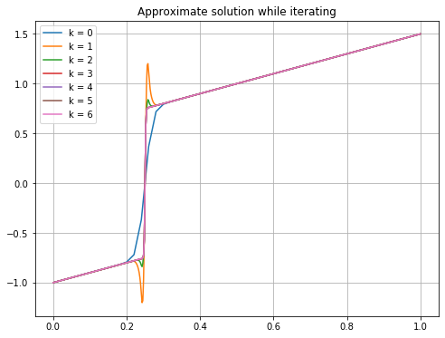

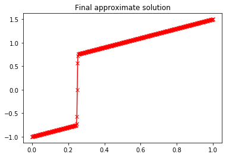

```python
epsilon = 0.001
m = 499
x,u = solve_bvp_nonlinear(epsilon, f, ainfo, binfo, m,  u0_func=u_01_func)

figure()
plot(x,u,'rx-')
title('Final approximate solution')
```